# Risk Factor Analysis

## Outcome Variable

**Outcome Variable:** whz

## Predictor Variables

**Intervention Variable:** nrooms

**Adjustment Set:**

- arm
- sex
- W_mage
- meducyrs
- feducyrs
- hhwealth_quart
- hfoodsec
- W_mhtcm
- W_mwtkg
- W_mbmi
- W_nchldlt5
- W_parity
- impfloor
- impsan
- safeh20
- delta_W_mage
- delta_meducyrs
- delta_feducyrs
- delta_hhwealth_quart
- delta_hfoodsec
- delta_W_mhtcm
- delta_W_mwtkg
- delta_W_mbmi
- delta_W_nchldlt5
- delta_W_parity
- delta_impfloor
- delta_impsan
- delta_safeh20

## Stratifying Variables

The analysis was stratified on these variable(s):

- agecat
- studyid
- country

## Data Summary

| agecat | studyid | country | nrooms | n_cell | n | outcome_variable |
| --- | --- | --- | --- | --- | --- | --- |
| Birth | CMC-V-BCS-2002 | INDIA | 4+ | 5 | 86 | whz |
| Birth | CMC-V-BCS-2002 | INDIA | 1 | 35 | 86 | whz |
| Birth | CMC-V-BCS-2002 | INDIA | 2 | 27 | 86 | whz |
| Birth | CMC-V-BCS-2002 | INDIA | 3 | 19 | 86 | whz |
| Birth | COHORTS | INDIA | 4+ | 90 | 4454 | whz |
| Birth | COHORTS | INDIA | 1 | 2879 | 4454 | whz |
| Birth | COHORTS | INDIA | 2 | 1328 | 4454 | whz |
| Birth | COHORTS | INDIA | 3 | 157 | 4454 | whz |
| Birth | CONTENT | PERU | 4+ | 1 | 2 | whz |
| Birth | CONTENT | PERU | 1 | 0 | 2 | whz |
| Birth | CONTENT | PERU | 2 | 1 | 2 | whz |
| Birth | CONTENT | PERU | 3 | 0 | 2 | whz |
| Birth | GMS-Nepal | NEPAL | 4+ | 297 | 641 | whz |
| Birth | GMS-Nepal | NEPAL | 1 | 42 | 641 | whz |
| Birth | GMS-Nepal | NEPAL | 2 | 135 | 641 | whz |
| Birth | GMS-Nepal | NEPAL | 3 | 167 | 641 | whz |
| Birth | IRC | INDIA | 4+ | 14 | 341 | whz |
| Birth | IRC | INDIA | 1 | 156 | 341 | whz |
| Birth | IRC | INDIA | 2 | 140 | 341 | whz |
| Birth | IRC | INDIA | 3 | 31 | 341 | whz |
| Birth | JiVitA-3 | BANGLADESH | 4+ | 662 | 17989 | whz |
| Birth | JiVitA-3 | BANGLADESH | 1 | 11170 | 17989 | whz |
| Birth | JiVitA-3 | BANGLADESH | 2 | 4609 | 17989 | whz |
| Birth | JiVitA-3 | BANGLADESH | 3 | 1548 | 17989 | whz |
| Birth | JiVitA-4 | BANGLADESH | 4+ | 111 | 2394 | whz |
| Birth | JiVitA-4 | BANGLADESH | 1 | 1430 | 2394 | whz |
| Birth | JiVitA-4 | BANGLADESH | 2 | 610 | 2394 | whz |
| Birth | JiVitA-4 | BANGLADESH | 3 | 243 | 2394 | whz |
| Birth | MAL-ED | BANGLADESH | 4+ | 12 | 201 | whz |
| Birth | MAL-ED | BANGLADESH | 1 | 121 | 201 | whz |

[output cut: 162 more lines]

The following strata were considered:

- agecat: 24 months, studyid: CMC-V-BCS-2002, country: INDIA
- agecat: 24 months, studyid: COHORTS, country: INDIA
- agecat: 24 months, studyid: CONTENT, country: PERU
- agecat: 24 months, studyid: GMS-Nepal, country: NEPAL
- agecat: 24 months, studyid: IRC, country: INDIA
- agecat: 24 months, studyid: JiVitA-3, country: BANGLADESH
- agecat: 24 months, studyid: JiVitA-4, country: BANGLADESH
- agecat: 24 months, studyid: MAL-ED, country: BANGLADESH
- agecat: 24 months, studyid: MAL-ED, country: BRAZIL
- agecat: 24 months, studyid: MAL-ED, country: INDIA
- agecat: 24 months, studyid: MAL-ED, country: NEPAL
- agecat: 24 months, studyid: MAL-ED, country: PERU
- agecat: 24 months, studyid: MAL-ED, country: SOUTH AFRICA
- agecat: 24 months, studyid: MAL-ED, country: TANZANIA, UNITED REPUBLIC OF
- agecat: 24 months, studyid: NIH-Crypto, country: BANGLADESH
- agecat: 24 months, studyid: PROVIDE, country: BANGLADESH
- agecat: 6 months, studyid: CMC-V-BCS-2002, country: INDIA
- agecat: 6 months, studyid: COHORTS, country: INDIA
- agecat: 6 months, studyid: CONTENT, country: PERU
- agecat: 6 months, studyid: GMS-Nepal, country: NEPAL
- agecat: 6 months, studyid: IRC, country: INDIA
- agecat: 6 months, studyid: JiVitA-3, country: BANGLADESH
- agecat: 6 months, studyid: JiVitA-4, country: BANGLADESH
- agecat: 6 months, studyid: MAL-ED, country: BANGLADESH
- agecat: 6 months, studyid: MAL-ED, country: BRAZIL
- agecat: 6 months, studyid: MAL-ED, country: INDIA
- agecat: 6 months, studyid: MAL-ED, country: NEPAL
- agecat: 6 months, studyid: MAL-ED, country: PERU
- agecat: 6 months, studyid: MAL-ED, country: SOUTH AFRICA
- agecat: 6 months, studyid: MAL-ED, country: TANZANIA, UNITED REPUBLIC OF
- agecat: 6 months, studyid: NIH-Crypto, country: BANGLADESH
- agecat: 6 months, studyid: PROVIDE, country: BANGLADESH
- agecat: Birth, studyid: CMC-V-BCS-2002, country: INDIA
- agecat: Birth, studyid: COHORTS, country: INDIA
- agecat: Birth, studyid: CONTENT, country: PERU
- agecat: Birth, studyid: GMS-Nepal, country: NEPAL
- agecat: Birth, studyid: IRC, country: INDIA
- agecat: Birth, studyid: JiVitA-3, country: BANGLADESH
- agecat: Birth, studyid: JiVitA-4, country: BANGLADESH
- agecat: Birth, studyid: MAL-ED, country: BANGLADESH
- agecat: Birth, studyid: MAL-ED, country: BRAZIL
- agecat: Birth, studyid: MAL-ED, country: INDIA
- agecat: Birth, studyid: MAL-ED, country: NEPAL
- agecat: Birth, studyid: MAL-ED, country: PERU
- agecat: Birth, studyid: MAL-ED, country: SOUTH AFRICA
- agecat: Birth, studyid: MAL-ED, country: TANZANIA, UNITED REPUBLIC OF
- agecat: Birth, studyid: NIH-Crypto, country: BANGLADESH
- agecat: Birth, studyid: PROVIDE, country: BANGLADESH

### Dropped Strata

Some strata were dropped due to rare outcomes:

- agecat: Birth, studyid: CONTENT, country: PERU
- agecat: Birth, studyid: MAL-ED, country: BRAZIL
- agecat: Birth, studyid: MAL-ED, country: INDIA
- agecat: Birth, studyid: MAL-ED, country: NEPAL
- agecat: 6 months, studyid: MAL-ED, country: BRAZIL
- agecat: 24 months, studyid: MAL-ED, country: BRAZIL

## Methods Detail

We’re interested in the causal parameters $E[Y_a]$ for all values of $a \in \mathcal{A}$. These parameters represent the mean outcome if, possibly contrary to fact, we intervened to set all units to have $A=a$. Under the randomization and positivity assumptions, these are identified by the statistical parameters $\psi_a=E_W[E_{Y|A,W}(Y|A=a,W)]$. In addition, we’re interested in the mean of $Y$, $E[Y]$ under no intervention (the observed mean). We will estimate these parameters by using SuperLearner to fit the relevant likelihood factors – $E_{Y|A,W}(Y|A=a,W)$ and $p(A=a|W)$, and then updating our likelihood fit using a joint TMLE.

For unadjusted analyses ($W=\{\}$), initial likelihoods were estimated using Lrnr_glm to estimate the simple $E(Y|A)$ and Lrnr_mean to estimate $p(A)$. For adjusted analyses, a small library containing Lrnr_glmnet, Lrnr_xgboost, and Lrnr_mean was used.

Having estimated these parameters, we will then use the delta method to estimate relative risks and attributable risks relative to a prespecified baseline level of $A$.

# Results Detail

## Results Plots

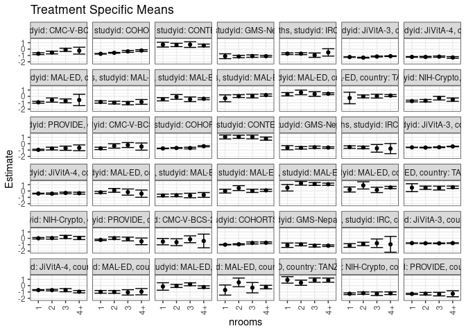

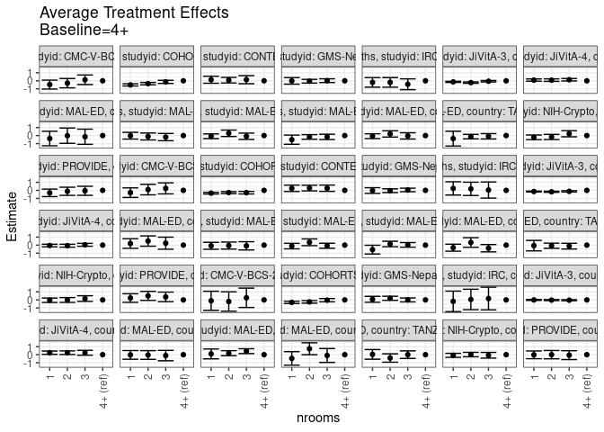

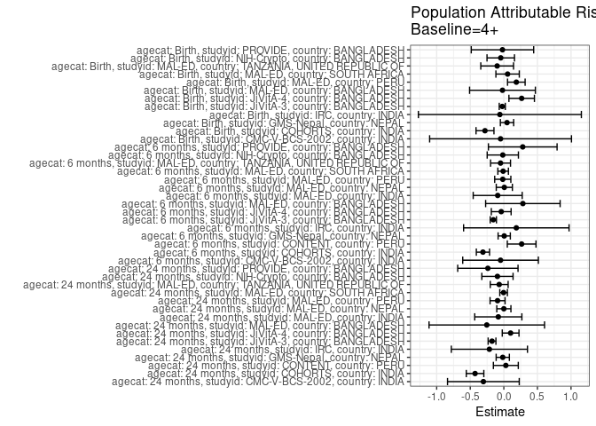

## Results Table

### Parameter: TSM

| agecat | studyid | country | intervention_level | baseline_level | estimate | ci_lower | ci_upper |
| --- | --- | --- | --- | --- | --- | --- | --- |
| Birth | CMC-V-BCS-2002 | INDIA | 4+ | NA | -0.4160000 | -1.4929959 | 0.6609959 |
| Birth | CMC-V-BCS-2002 | INDIA | 1 | NA | -0.5244286 | -1.0232807 | -0.0255765 |
| Birth | CMC-V-BCS-2002 | INDIA | 2 | NA | -0.6155556 | -1.1573805 | -0.0737306 |
| Birth | CMC-V-BCS-2002 | INDIA | 3 | NA | -0.1536842 | -0.6942308 | 0.3868624 |
| Birth | COHORTS | INDIA | 4+ | NA | -0.6972032 | -0.8303412 | -0.5640652 |
| Birth | COHORTS | INDIA | 1 | NA | -1.0016123 | -1.0472184 | -0.9560062 |
| Birth | COHORTS | INDIA | 2 | NA | -0.9427329 | -1.0232016 | -0.8622641 |
| Birth | COHORTS | INDIA | 3 | NA | -0.7287141 | -0.8842644 | -0.5731637 |
| Birth | GMS-Nepal | NEPAL | 4+ | NA | -1.1638193 | -1.2911576 | -1.0364810 |
| Birth | GMS-Nepal | NEPAL | 1 | NA | -1.0863106 | -1.4334620 | -0.7391593 |
| Birth | GMS-Nepal | NEPAL | 2 | NA | -0.9644807 | -1.1838087 | -0.7451526 |
| Birth | GMS-Nepal | NEPAL | 3 | NA | -1.1652926 | -1.3739619 | -0.9566234 |
| Birth | IRC | INDIA | 4+ | NA | -0.9462709 | -2.1910400 | 0.2984983 |
| Birth | IRC | INDIA | 1 | NA | -1.1268886 | -1.4169487 | -0.8368285 |
| Birth | IRC | INDIA | 2 | NA | -0.8901031 | -1.1595785 | -0.6206276 |
| Birth | IRC | INDIA | 3 | NA | -0.7761864 | -1.4450361 | -0.1073368 |
| Birth | JiVitA-3 | BANGLADESH | 4+ | NA | -0.7543212 | -0.7983347 | -0.7103077 |
| Birth | JiVitA-3 | BANGLADESH | 1 | NA | -0.7564662 | -0.7883188 | -0.7246135 |
| Birth | JiVitA-3 | BANGLADESH | 2 | NA | -0.7786349 | -0.8248538 | -0.7324160 |
| Birth | JiVitA-3 | BANGLADESH | 3 | NA | -0.7893625 | -0.8415812 | -0.7371437 |
| Birth | JiVitA-4 | BANGLADESH | 4+ | NA | -0.9536813 | -1.1450065 | -0.7623562 |
| Birth | JiVitA-4 | BANGLADESH | 1 | NA | -0.7047084 | -0.7738254 | -0.6355913 |
| Birth | JiVitA-4 | BANGLADESH | 2 | NA | -0.7082797 | -0.8305841 | -0.5859753 |
| Birth | JiVitA-4 | BANGLADESH | 3 | NA | -0.7142568 | -0.9586607 | -0.4698530 |
| Birth | MAL-ED | BANGLADESH | 4+ | NA | -0.9525990 | -1.4475942 | -0.4576039 |
| Birth | MAL-ED | BANGLADESH | 1 | NA | -0.9789768 | -1.1948212 | -0.7631325 |
| Birth | MAL-ED | BANGLADESH | 2 | NA | -0.9930416 | -1.2158323 | -0.7702509 |
| Birth | MAL-ED | BANGLADESH | 3 | NA | -1.0651097 | -1.4852229 | -0.6449966 |
| Birth | MAL-ED | PERU | 4+ | NA | -0.2326768 | -0.4261126 | -0.0392411 |
| Birth | MAL-ED | PERU | 1 | NA | -0.1380757 | -0.7252307 | 0.4490794 |

[output cut: 138 more lines]

### Parameter: E(Y)

| agecat | studyid | country | intervention_level | baseline_level | estimate | ci_lower | ci_upper |
| --- | --- | --- | --- | --- | --- | --- | --- |
| Birth | CMC-V-BCS-2002 | INDIA | NA | NA | -0.4648256 | -0.7643210 | -0.1653302 |
| Birth | COHORTS | INDIA | NA | NA | -0.9778087 | -1.0126530 | -0.9429644 |
| Birth | GMS-Nepal | NEPAL | NA | NA | -1.1164431 | -1.2040134 | -1.0288728 |
| Birth | IRC | INDIA | NA | NA | -1.0053372 | -1.1922119 | -0.8184626 |
| Birth | JiVitA-3 | BANGLADESH | NA | NA | -0.7776536 | -0.7966730 | -0.7586341 |
| Birth | JiVitA-4 | BANGLADESH | NA | NA | -0.6882498 | -0.7406539 | -0.6358456 |
| Birth | MAL-ED | BANGLADESH | NA | NA | -0.9728358 | -1.1217009 | -0.8239707 |
| Birth | MAL-ED | PERU | NA | NA | -0.0468095 | -0.1738806 | 0.0802616 |
| Birth | MAL-ED | SOUTH AFRICA | NA | NA | -0.1729474 | -0.4186222 | 0.0727275 |
| Birth | MAL-ED | TANZANIA, UNITED REPUBLIC OF | NA | NA | 0.7637500 | 0.5676177 | 0.9598823 |
| Birth | NIH-Crypto | BANGLADESH | NA | NA | -1.2441513 | -1.3281130 | -1.1601897 |
| Birth | PROVIDE | BANGLADESH | NA | NA | -1.2984586 | -1.3752758 | -1.2216415 |
| 6 months | CMC-V-BCS-2002 | INDIA | NA | NA | -0.5026766 | -0.6536848 | -0.3516685 |
| 6 months | COHORTS | INDIA | NA | NA | -0.7088012 | -0.7411274 | -0.6764750 |
| 6 months | CONTENT | PERU | NA | NA | 1.0644279 | 0.9468682 | 1.1819876 |
| 6 months | GMS-Nepal | NEPAL | NA | NA | -0.6038416 | -0.6899448 | -0.5177384 |
| 6 months | IRC | INDIA | NA | NA | -0.5900821 | -0.7252457 | -0.4549185 |
| 6 months | JiVitA-3 | BANGLADESH | NA | NA | -0.5930302 | -0.6125738 | -0.5734865 |
| 6 months | JiVitA-4 | BANGLADESH | NA | NA | -0.3901595 | -0.4274150 | -0.3529041 |
| 6 months | MAL-ED | BANGLADESH | NA | NA | -0.1333333 | -0.2623761 | -0.0042906 |
| 6 months | MAL-ED | INDIA | NA | NA | -0.7102872 | -0.8371659 | -0.5834085 |
| 6 months | MAL-ED | NEPAL | NA | NA | 0.1104308 | -0.0208643 | 0.2417259 |
| 6 months | MAL-ED | PERU | NA | NA | 1.0512099 | 0.9285617 | 1.1738581 |
| 6 months | MAL-ED | SOUTH AFRICA | NA | NA | 0.5404351 | 0.3867005 | 0.6941696 |
| 6 months | MAL-ED | TANZANIA, UNITED REPUBLIC OF | NA | NA | 0.5362213 | 0.4049390 | 0.6675036 |
| 6 months | NIH-Crypto | BANGLADESH | NA | NA | 0.0297622 | -0.0491685 | 0.1086930 |
| 6 months | PROVIDE | BANGLADESH | NA | NA | -0.1990907 | -0.2817968 | -0.1163845 |
| 24 months | CMC-V-BCS-2002 | INDIA | NA | NA | -0.5571505 | -0.6585247 | -0.4557763 |
| 24 months | COHORTS | INDIA | NA | NA | -0.6612799 | -0.6944511 | -0.6281088 |
| 24 months | CONTENT | PERU | NA | NA | 0.5902439 | 0.4560143 | 0.7244735 |
| 24 months | GMS-Nepal | NEPAL | NA | NA | -1.1363107 | -1.2252817 | -1.0473398 |
| 24 months | IRC | INDIA | NA | NA | -0.7416790 | -0.8323562 | -0.6510017 |
| 24 months | JiVitA-3 | BANGLADESH | NA | NA | -1.2967966 | -1.3200807 | -1.2735126 |
| 24 months | JiVitA-4 | BANGLADESH | NA | NA | -1.2231776 | -1.2550332 | -1.1913220 |
| 24 months | MAL-ED | BANGLADESH | NA | NA | -0.8192925 | -0.9412667 | -0.6973182 |
| 24 months | MAL-ED | INDIA | NA | NA | -0.9516520 | -1.0670654 | -0.8362385 |
| 24 months | MAL-ED | NEPAL | NA | NA | -0.3749123 | -0.4886073 | -0.2612173 |
| 24 months | MAL-ED | PERU | NA | NA | 0.1111982 | -0.0118399 | 0.2342362 |
| 24 months | MAL-ED | SOUTH AFRICA | NA | NA | 0.4090301 | 0.2879441 | 0.5301161 |
| 24 months | MAL-ED | TANZANIA, UNITED REPUBLIC OF | NA | NA | 0.0547975 | -0.0703378 | 0.1799328 |
| 24 months | NIH-Crypto | BANGLADESH | NA | NA | -0.6103502 | -0.7050157 | -0.5156847 |
| 24 months | PROVIDE | BANGLADESH | NA | NA | -0.8928670 | -0.9755153 | -0.8102187 |

### Parameter: ATE

| agecat | studyid | country | intervention_level | baseline_level | estimate | ci_lower | ci_upper |
| --- | --- | --- | --- | --- | --- | --- | --- |
| Birth | CMC-V-BCS-2002 | INDIA | 4+ | 4+ | 0.0000000 | 0.0000000 | 0.0000000 |
| Birth | CMC-V-BCS-2002 | INDIA | 1 | 4+ | -0.1084286 | -1.2953462 | 1.0784891 |
| Birth | CMC-V-BCS-2002 | INDIA | 2 | 4+ | -0.1995556 | -1.4051651 | 1.0060540 |
| Birth | CMC-V-BCS-2002 | INDIA | 3 | 4+ | 0.2623158 | -0.9427198 | 1.4673514 |
| Birth | COHORTS | INDIA | 4+ | 4+ | 0.0000000 | 0.0000000 | 0.0000000 |
| Birth | COHORTS | INDIA | 1 | 4+ | -0.3044091 | -0.4450290 | -0.1637892 |
| Birth | COHORTS | INDIA | 2 | 4+ | -0.2455296 | -0.4010682 | -0.0899911 |
| Birth | COHORTS | INDIA | 3 | 4+ | -0.0315108 | -0.2361976 | 0.1731759 |
| Birth | GMS-Nepal | NEPAL | 4+ | 4+ | 0.0000000 | 0.0000000 | 0.0000000 |
| Birth | GMS-Nepal | NEPAL | 1 | 4+ | 0.0775087 | -0.2921869 | 0.4472043 |
| Birth | GMS-Nepal | NEPAL | 2 | 4+ | 0.1993386 | -0.0538334 | 0.4525107 |
| Birth | GMS-Nepal | NEPAL | 3 | 4+ | -0.0014733 | -0.2459226 | 0.2429760 |
| Birth | IRC | INDIA | 4+ | 4+ | 0.0000000 | 0.0000000 | 0.0000000 |
| Birth | IRC | INDIA | 1 | 4+ | -0.1806178 | -1.4591913 | 1.0979558 |
| Birth | IRC | INDIA | 2 | 4+ | 0.0561678 | -1.2175926 | 1.3299282 |
| Birth | IRC | INDIA | 3 | 4+ | 0.1700844 | -1.2425535 | 1.5827224 |
| Birth | JiVitA-3 | BANGLADESH | 4+ | 4+ | 0.0000000 | 0.0000000 | 0.0000000 |
| Birth | JiVitA-3 | BANGLADESH | 1 | 4+ | -0.0021450 | -0.0557229 | 0.0514330 |
| Birth | JiVitA-3 | BANGLADESH | 2 | 4+ | -0.0243137 | -0.0882025 | 0.0395751 |
| Birth | JiVitA-3 | BANGLADESH | 3 | 4+ | -0.0350413 | -0.1014545 | 0.0313719 |
| Birth | JiVitA-4 | BANGLADESH | 4+ | 4+ | 0.0000000 | 0.0000000 | 0.0000000 |
| Birth | JiVitA-4 | BANGLADESH | 1 | 4+ | 0.2489729 | 0.0465513 | 0.4513946 |
| Birth | JiVitA-4 | BANGLADESH | 2 | 4+ | 0.2454016 | 0.0193003 | 0.4715029 |
| Birth | JiVitA-4 | BANGLADESH | 3 | 4+ | 0.2394245 | -0.0646156 | 0.5434645 |
| Birth | MAL-ED | BANGLADESH | 4+ | 4+ | 0.0000000 | 0.0000000 | 0.0000000 |
| Birth | MAL-ED | BANGLADESH | 1 | 4+ | -0.0263778 | -0.5667250 | 0.5139694 |
| Birth | MAL-ED | BANGLADESH | 2 | 4+ | -0.0404426 | -0.5833976 | 0.5025125 |
| Birth | MAL-ED | BANGLADESH | 3 | 4+ | -0.1125107 | -0.7596368 | 0.5346154 |
| Birth | MAL-ED | PERU | 4+ | 4+ | 0.0000000 | 0.0000000 | 0.0000000 |
| Birth | MAL-ED | PERU | 1 | 4+ | 0.0946012 | -0.5212316 | 0.7104339 |

[output cut: 138 more lines]

### Parameter: PAR

| agecat | studyid | country | intervention_level | baseline_level | estimate | ci_lower | ci_upper |
| --- | --- | --- | --- | --- | --- | --- | --- |
| Birth | CMC-V-BCS-2002 | INDIA | 4+ | NA | -0.0488256 | -1.1046396 | 1.0069884 |
| Birth | COHORTS | INDIA | 4+ | NA | -0.2806055 | -0.4140211 | -0.1471899 |
| Birth | GMS-Nepal | NEPAL | 4+ | NA | 0.0473763 | -0.0516044 | 0.1463569 |
| Birth | IRC | INDIA | 4+ | NA | -0.0590664 | -1.2722720 | 1.1541392 |
| Birth | JiVitA-3 | BANGLADESH | 4+ | NA | -0.0233324 | -0.0685435 | 0.0218788 |
| Birth | JiVitA-4 | BANGLADESH | 4+ | NA | 0.2654315 | 0.0755699 | 0.4552931 |
| Birth | MAL-ED | BANGLADESH | 4+ | NA | -0.0202368 | -0.5099560 | 0.4694824 |
| Birth | MAL-ED | PERU | 4+ | NA | 0.1858673 | 0.0550207 | 0.3167139 |
| Birth | MAL-ED | SOUTH AFRICA | 4+ | NA | 0.0558405 | -0.1182633 | 0.2299443 |
| Birth | MAL-ED | TANZANIA, UNITED REPUBLIC OF | 4+ | NA | -0.0993611 | -0.3431773 | 0.1444551 |
| Birth | NIH-Crypto | BANGLADESH | 4+ | NA | -0.0459791 | -0.2504766 | 0.1585184 |
| Birth | PROVIDE | BANGLADESH | 4+ | NA | -0.0205378 | -0.4852282 | 0.4441526 |
| 6 months | CMC-V-BCS-2002 | INDIA | 4+ | NA | -0.0489775 | -0.6119856 | 0.5140306 |
| 6 months | COHORTS | INDIA | 4+ | NA | -0.3111689 | -0.4093425 | -0.2129954 |
| 6 months | CONTENT | PERU | 4+ | NA | 0.2650518 | 0.0516214 | 0.4784821 |
| 6 months | GMS-Nepal | NEPAL | 4+ | NA | 0.0055543 | -0.0854010 | 0.0965097 |
| 6 months | IRC | INDIA | 4+ | NA | 0.1858857 | -0.5990632 | 0.9708345 |
| 6 months | JiVitA-3 | BANGLADESH | 4+ | NA | -0.1566089 | -0.2030129 | -0.1102049 |
| 6 months | JiVitA-4 | BANGLADESH | 4+ | NA | -0.0390800 | -0.1863808 | 0.1082207 |
| 6 months | MAL-ED | BANGLADESH | 4+ | NA | 0.2834891 | -0.2709722 | 0.8379503 |
| 6 months | MAL-ED | INDIA | 4+ | NA | -0.0913440 | -0.4562365 | 0.2735485 |
| 6 months | MAL-ED | NEPAL | 4+ | NA | 0.0070540 | -0.1129702 | 0.1270781 |
| 6 months | MAL-ED | PERU | 4+ | NA | -0.0160014 | -0.1362936 | 0.1042909 |
| 6 months | MAL-ED | SOUTH AFRICA | 4+ | NA | -0.0104743 | -0.0890906 | 0.0681419 |
| 6 months | MAL-ED | TANZANIA, UNITED REPUBLIC OF | 4+ | NA | -0.0491033 | -0.1973789 | 0.0991723 |
| 6 months | NIH-Crypto | BANGLADESH | 4+ | NA | -0.0156370 | -0.2480423 | 0.2167684 |
| 6 months | PROVIDE | BANGLADESH | 4+ | NA | 0.2813851 | -0.2297793 | 0.7925495 |
| 24 months | CMC-V-BCS-2002 | INDIA | 4+ | NA | -0.3045676 | -0.8384841 | 0.2293489 |
| 24 months | COHORTS | INDIA | 4+ | NA | -0.4284302 | -0.5589979 | -0.2978625 |
| 24 months | CONTENT | PERU | 4+ | NA | 0.0296167 | -0.1557610 | 0.2149945 |
| 24 months | GMS-Nepal | NEPAL | 4+ | NA | -0.0161349 | -0.1143913 | 0.0821216 |
| 24 months | IRC | INDIA | 4+ | NA | -0.2149033 | -0.7815449 | 0.3517383 |
| 24 months | JiVitA-3 | BANGLADESH | 4+ | NA | -0.1758299 | -0.2336837 | -0.1179760 |
| 24 months | JiVitA-4 | BANGLADESH | 4+ | NA | 0.1008545 | -0.0236721 | 0.2253810 |
| 24 months | MAL-ED | BANGLADESH | 4+ | NA | -0.2537591 | -1.1134090 | 0.6058908 |
| 24 months | MAL-ED | INDIA | 4+ | NA | -0.0824623 | -0.4334169 | 0.2684924 |
| 24 months | MAL-ED | NEPAL | 4+ | NA | 0.0002066 | -0.1049120 | 0.1053251 |
| 24 months | MAL-ED | PERU | 4+ | NA | -0.0934569 | -0.2050271 | 0.0181133 |
| 24 months | MAL-ED | SOUTH AFRICA | 4+ | NA | -0.0037171 | -0.0603120 | 0.0528777 |
| 24 months | MAL-ED | TANZANIA, UNITED REPUBLIC OF | 4+ | NA | -0.0689440 | -0.2018628 | 0.0639748 |
| 24 months | NIH-Crypto | BANGLADESH | 4+ | NA | -0.0951544 | -0.3276396 | 0.1373308 |
| 24 months | PROVIDE | BANGLADESH | 4+ | NA | -0.2377505 | -0.6867942 | 0.2112931 |